# Bagging and Random Forests Assignment

Granger Moch, Sam Eckhardt

March 31, 2015

### Load Packages and Carseats Dataset

```r
library(ISLR)
library(ggplot2)
library(RcmdrMisc)
library(BCA)
library(rpart)
library(rpart.plot)
library(randomForest)
library(ROCR)

Carseats=data.frame(Carseats)
```

### Create Binary Variable and Samples

```r
Carseats$High<- as.factor(ifelse(Carseats$Sales <= 8, "No", "Yes"))
Carseats$Sample= create.samples(Carseats, est = 0.50, val = 0.50, rand.seed = 1)
```

### Explore Factor Variables with Plots of Means

```r
summary(Carseats)
```

```
##      Sales          CompPrice       Income        Advertising
##  Min.   : 0.000   Min.   : 77   Min.   : 21.00   Min.   : 0.000
##  1st Qu.: 5.390   1st Qu.:115   1st Qu.: 42.75   1st Qu.: 0.000
##  Median : 7.490   Median :125   Median : 69.00   Median : 5.000
##  Mean   : 7.496   Mean   :125   Mean   : 68.66   Mean   : 6.635
##  3rd Qu.: 9.320   3rd Qu.:135   3rd Qu.: 91.00   3rd Qu.:12.000
##  Max.   :16.270   Max.   :175   Max.   :120.00   Max.   :29.000
##    Population        Price        ShelveLoc        Age
##  Min.   : 10.0   Min.   : 24.0   Bad   : 96   Min.   :25.00
##  1st Qu.:139.0   1st Qu.:100.0   Good  : 85   1st Qu.:39.75
##  Median :272.0   Median :117.0   Medium:219   Median :54.50
##  Mean   :264.8   Mean   :115.8                Mean   :53.32
##  3rd Qu.:398.5   3rd Qu.:131.0                3rd Qu.:66.00
##  Max.   :509.0   Max.   :191.0                Max.   :80.00
##    Education    Urban       US       High        Sample
##  Min.   :10.0   No :118   No :142   No :236   Length:400
##  1st Qu.:12.0   Yes:282   Yes:258   Yes:164   Class :character
##  Median :14.0                                 Mode  :character
##  Mean   :13.9
##  3rd Qu.:16.0
##  Max.   :18.0
```

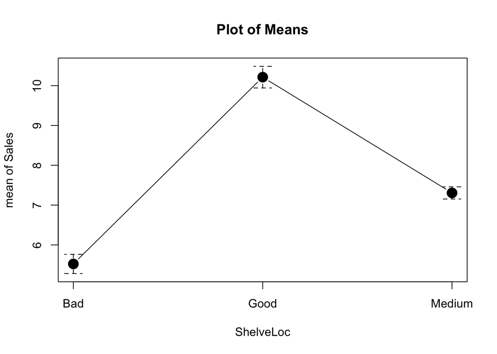

```r
#ShelveLoc Factor
with(Carseats, plotMeans(Sales, ShelveLoc, error.bars="se"))
```

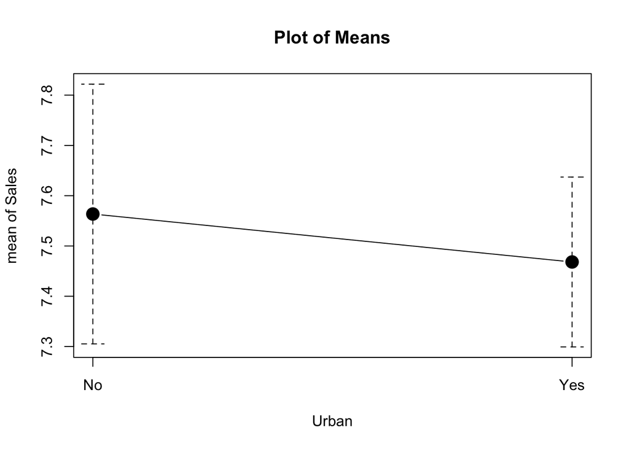

```r
#Urban factor
with(Carseats, plotMeans(Sales, Urban, error.bars="se"))
```

It seems that good shelf space likely contributes to higher sales, as one would expect. As for whether a person is from an urban area or not, there doesn’t seem to be too significant of a difference in sales.

### Explore Data Further

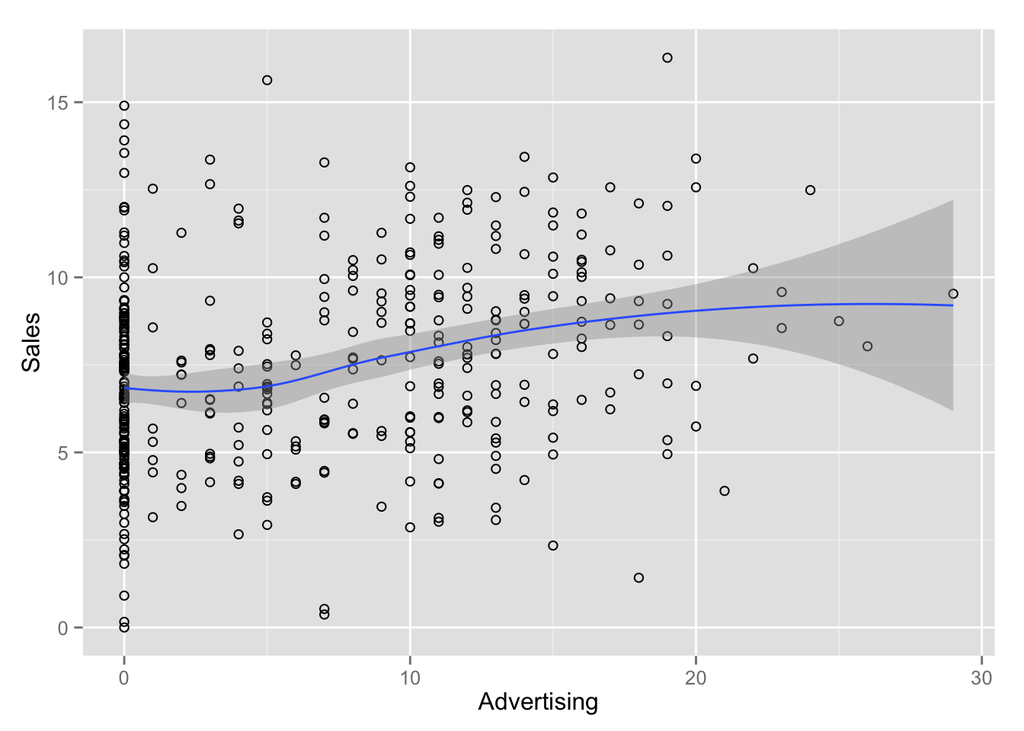

```r
ggplot(Carseats, aes(x=Advertising, y=Sales)) +
    geom_point(shape=1) +geom_smooth(stat="smooth")
```

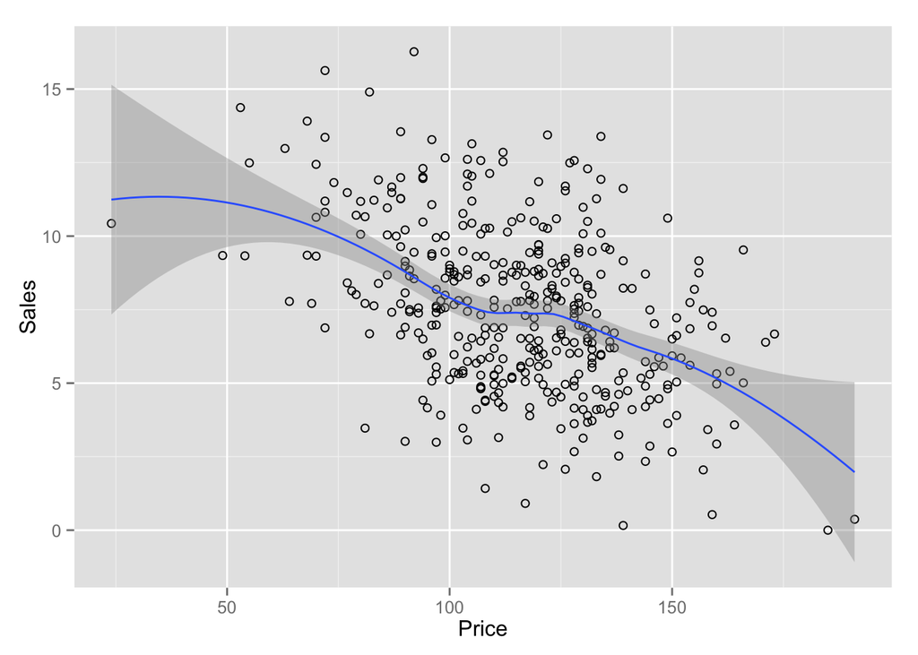

```r
ggplot(Carseats, aes(x=Price, y=Sales)) +
    geom_point(shape=1) +geom_smooth(stat="smooth")
```

Advertising does seem to contribute to higher sales, while higher prices indicate decreased sales.

### Create Logistic Regression Model

```r
CarseatsModel1= glm(High~ Income+ ShelveLoc + Education + Urban + US + CompPrice + Advertising, family=binomial(logit), data=Carseats, subset=Sample== "Estimation")
```

### Assess Model

```r
summary(CarseatsModel1)
```

```
##
## Call:
## glm(formula = High ~ Income + ShelveLoc + Education + Urban +
##     US + CompPrice + Advertising, family = binomial(logit), data = Carseats,
##     subset = Sample == "Estimation")
##
## Deviance Residuals:
##     Min       1Q   Median       3Q      Max
## -1.8882  -0.7589  -0.4107   0.7158   2.3326
##
## Coefficients:
##                  Estimate Std. Error z value Pr(>|z|)
## (Intercept)     -3.538325   1.929451  -1.834 0.066676 .
## Income           0.019561   0.006575   2.975 0.002928 **
## ShelveLocGood    3.323043   0.610152   5.446 5.14e-08 ***
## ShelveLocMedium  1.572925   0.530161   2.967 0.003008 **
## Education       -0.040123   0.066312  -0.605 0.545139
## UrbanYes        -0.664240   0.394364  -1.684 0.092117 .
## USYes           -0.473995   0.549889  -0.862 0.388697
## CompPrice        0.003652   0.011628   0.314 0.753500
## Advertising      0.163270   0.046423   3.517 0.000436 ***
## ---
## Signif. codes:  0 '***' 0.001 '**' 0.01 '*' 0.05 '.' 0.1 ' ' 1
##
## (Dispersion parameter for binomial family taken to be 1)
##
##     Null deviance: 270.74  on 199  degrees of freedom
## Residual deviance: 195.56  on 191  degrees of freedom
## AIC: 213.56
##
## Number of Fisher Scoring iterations: 5
```

```r
1 - (CarseatsModel1$deviance/CarseatsModel1$null.deviance) #McFadden R2
```

```
## [1] 0.2776745
```

The variables ShelveLoc, Advertising, and Income appear to be highly significant, while Education, CompPrice, and US appear to be insignificant.

### Create Second Model

```r
CarseatsModel2= glm(High~ Income+ ShelveLoc + Urban + Advertising, family=binomial(logit), data=Carseats, subset=Sample== "Estimation")

summary(CarseatsModel2)
```

```
##
## Call:
## glm(formula = High ~ Income + ShelveLoc + Urban + Advertising,
##     family = binomial(logit), data = Carseats, subset = Sample ==
##         "Estimation")
##
## Deviance Residuals:
##     Min       1Q   Median       3Q      Max
## -1.8586  -0.7549  -0.4184   0.7563   2.2951
##
## Coefficients:
##                  Estimate Std. Error z value Pr(>|z|)
## (Intercept)     -3.702964   0.790777  -4.683 2.83e-06 ***
## Income           0.019064   0.006419   2.970  0.00298 **
## ShelveLocGood    3.335296   0.604988   5.513 3.53e-08 ***
## ShelveLocMedium  1.579376   0.520188   3.036  0.00240 **
## UrbanYes        -0.671211   0.395554  -1.697  0.08972 .
## Advertising      0.133080   0.030621   4.346 1.39e-05 ***
## ---
## Signif. codes:  0 '***' 0.001 '**' 0.01 '*' 0.05 '.' 0.1 ' ' 1
##
## (Dispersion parameter for binomial family taken to be 1)
##
##     Null deviance: 270.74  on 199  degrees of freedom
## Residual deviance: 196.72  on 194  degrees of freedom
## AIC: 208.72
##
## Number of Fisher Scoring iterations: 5
```

```r
1 - (CarseatsModel2$deviance/CarseatsModel2$null.deviance) # McFadden R2
```

```
## [1] 0.2734124
```

The AIC is minimized with this model, so we will select this second model for use.

### Decision Tree

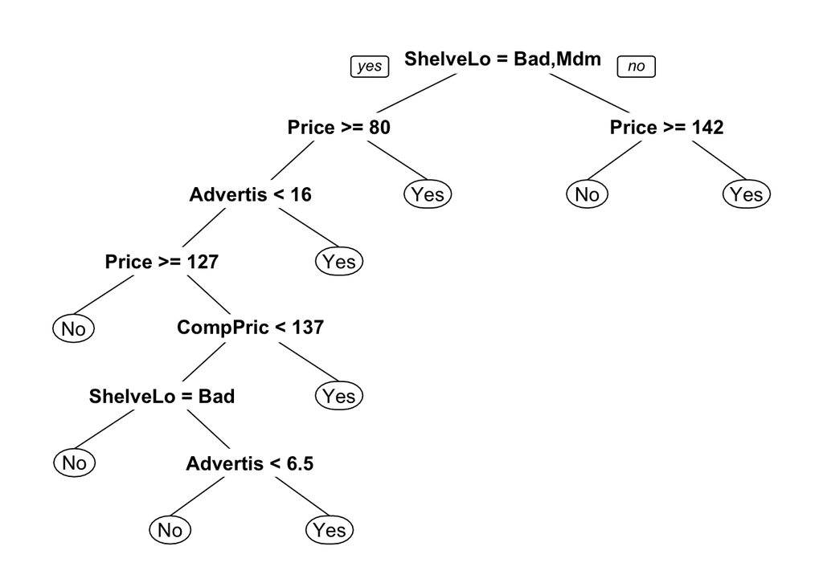

```r
carTree <- rpart(High~ Income+ Price+ Population+ ShelveLoc + Education + Urban + US + CompPrice + Advertising, data = Carseats, cp = 0.001, subset = Sample == "Estimation")

rpart.plot(carTree)
```

### Identify Minimum CP Value

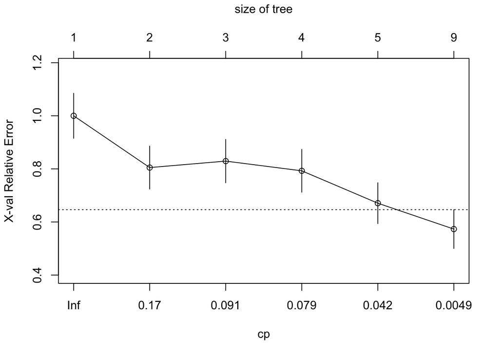

```r
plotcp(carTree)
```

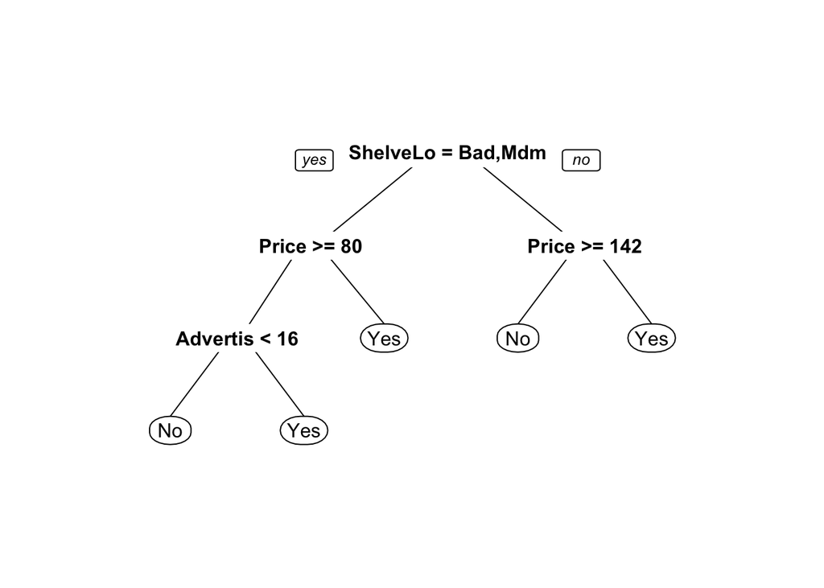

```r
carTreePruned <- prune(carTree, cp=.049)

rpart.plot(carTreePruned)
```

### Bagging

```r
set.seed(1)

baggingCarseats = randomForest(High~ Income+ Price+ Population+ ShelveLoc + Education + Urban + US + CompPrice + Advertising, data = Carseats[Carseats$Sample == "Estimation",
    ], mtry = 9, importance = TRUE)

baggingCarseats
```

```
##
## Call:
##  randomForest(formula = High ~ Income + Price + Population + ShelveLoc +      Education + Urban + US + CompPrice + Advertising, data = Carseats[Carseats$Sample ==      "Estimation", ], mtry = 9, importance = TRUE)
##                Type of random forest: classification
##                      Number of trees: 500
## No. of variables tried at each split: 9
##
##         OOB estimate of  error rate: 20.5%
## Confusion matrix:
##      No Yes class.error
## No  101  17   0.1440678
## Yes  24  58   0.2926829
```

### Assess Variable Importance

```r
importance(baggingCarseats)
```

```
##                    No       Yes MeanDecreaseAccuracy MeanDecreaseGini
## Income       4.960381  5.943646             7.623530       11.0570119
## Price       24.857152 22.073247            31.280494       28.9017522
## Population   2.975742  2.912475             4.099915        9.3413063
## ShelveLoc   30.585965 22.814837            35.559309       16.3263914
## Education    1.222542  1.045517             1.573552        4.9098782
## Urban       -1.197940 -1.207237            -1.570402        0.5773059
## US           1.639628  3.449363             3.569074        0.4337827
## CompPrice    8.293838  1.080410             7.123481       10.8065498
## Advertising 10.104965 14.323158            16.093076       13.7784616
```

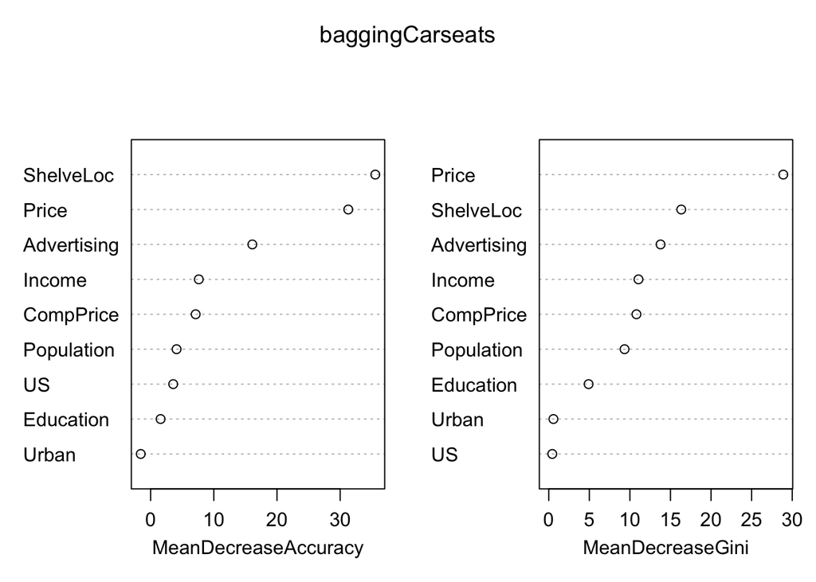

```r
varImpPlot(baggingCarseats)
```

Shelf Location, Price, Advertising are clearly the most important variables in the dataset, as their invidual absence from the model leads to the largest mean decreases in both accuracy and the gini index. On the other hand, Urban, Education, and US appear to be the least significant variables in this dataset.

### Random Forest

```r
RfCarseats = randomForest(High~ Income+ Price+ Population+ ShelveLoc + Education + Urban + US + CompPrice + Advertising, data = Carseats[Carseats$Sample == "Estimation",
    ],importance = TRUE)

RfCarseats
```

```
##
## Call:
##  randomForest(formula = High ~ Income + Price + Population + ShelveLoc +      Education + Urban + US + CompPrice + Advertising, data = Carseats[Carseats$Sample ==      "Estimation", ], importance = TRUE)
##                Type of random forest: classification
##                      Number of trees: 500
## No. of variables tried at each split: 3
##
##         OOB estimate of  error rate: 19%
## Confusion matrix:
##      No Yes class.error
## No  104  14   0.1186441
## Yes  24  58   0.2926829
```

### ROCR Predicition/Preformance Data

### Gains Chart Estimation Data

```r
#Gains Chart Estimation Data
```

```r
act_estim = Carseats[Carseats$Sample == "Estimation", ]$High

# for logistic regression
estimpredglm = predict(CarseatsModel2, newdata = Carseats[Carseats$Sample == "Estimation", ], type = "response")

estimrocrpredglm = prediction(estimpredglm, act_estim)
estimrocrperfglm = performance(estimrocrpredglm, "tpr", "rpp")

# for logistic regression (initial model)
estimpredglmOld = predict(CarseatsModel1, newdata = Carseats[Carseats$Sample == "Estimation", ], type = "response")

estimrocrpredglmOld = prediction(estimpredglmOld, act_estim)
estimrocrperfglmOld = performance(estimrocrpredglmOld, "tpr", "rpp")

#for tree
estimpredTree = predict(carTreePruned, type = "prob", newdata = Carseats[Carseats$Sample == "Estimation", ])

estimrocrpredTree = prediction(estimpredTree[, 2], act_estim)
estimrocrperfTree = performance(estimrocrpredTree, "tpr", "rpp")

#for bagging
estimpredBag = predict(baggingCarseats, type = "prob", newdata = Carseats[Carseats$Sample == "Estimation", ])

estimrocrpredBag = prediction(estimpredBag[, 2], act_estim)
estimrocrperfBag = performance(estimrocrpredBag, "tpr", "rpp")

#random forest
estimpredRF = predict(RfCarseats, type = "prob", newdata = Carseats[Carseats$Sample == "Estimation", ])

estimrocrpredRF = prediction(estimpredRF[, 2], act_estim)
estimrocrperfRF = performance(estimrocrpredRF, "tpr", "rpp")
```

### Gains Chart Validation Data

```r
act_estim1 = Carseats[Carseats$Sample == "Validation", ]$High

# for logistic regression
estimpredglm1 = predict(CarseatsModel2, newdata = Carseats[Carseats$Sample == "Validation", ], type = "response")

estimrocrpredglm1 = prediction(estimpredglm1, act_estim1)
estimrocrperfglm1 = performance(estimrocrpredglm1, "tpr", "rpp")

# for logistic regression (initial model)
estimpredglmOld1 = predict(CarseatsModel1, newdata = Carseats[Carseats$Sample == "Validation", ], type = "response")

estimrocrpredglmOld1= prediction(estimpredglmOld1, act_estim1)
estimrocrperfglmOld1 = performance(estimrocrpredglmOld1, "tpr", "rpp")

#for tree
estimpredTree1 = predict(carTreePruned, type = "prob", newdata = Carseats[Carseats$Sample == "Validation", ])

estimrocrpredTree1 = prediction(estimpredTree1[, 2], act_estim1)
estimrocrperfTree1 = performance(estimrocrpredTree1, "tpr", "rpp")

#for bagging
estimpredBag1 = predict(baggingCarseats, type = "prob", newdata = Carseats[Carseats$Sample == "Validation", ])

estimrocrpredBag1 = prediction(estimpredBag1[, 2], act_estim1)
estimrocrperfBag1 = performance(estimrocrpredBag1, "tpr", "rpp")

#random forest
estimpredRF1 = predict(RfCarseats, type = "prob", newdata = Carseats[Carseats$Sample == "Validation", ])

estimrocrpredRF1 = prediction(estimpredRF1[, 2], act_estim1)
estimrocrperfRF1 = performance(estimrocrpredRF1, "tpr", "rpp")
```

### Gains Charts (Estimation Data)

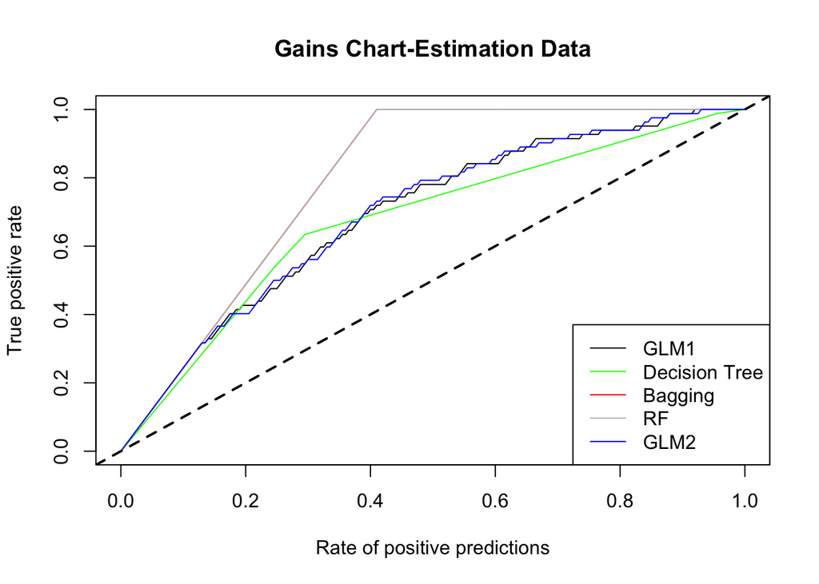

### Gains Charts (Validation Data)

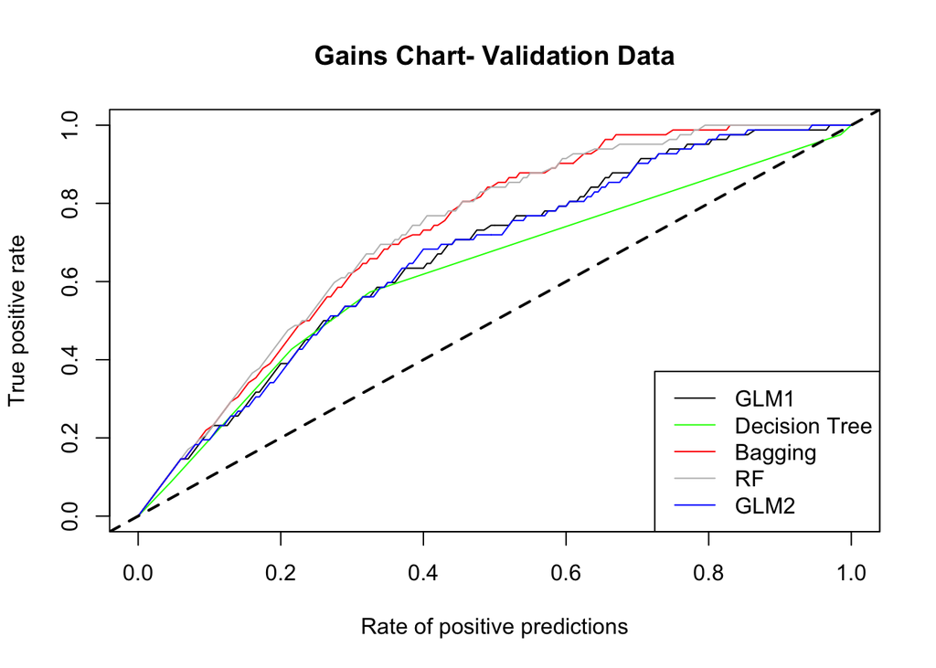

### ROC Curve (Estimation)

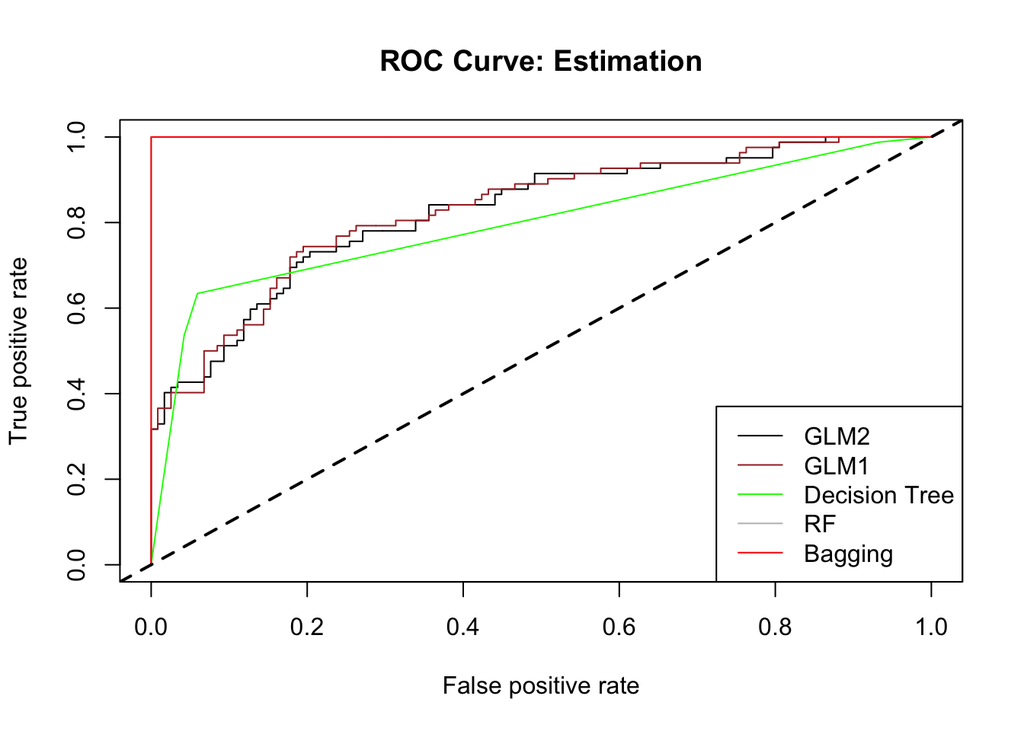

### ROC Curve (Validation)

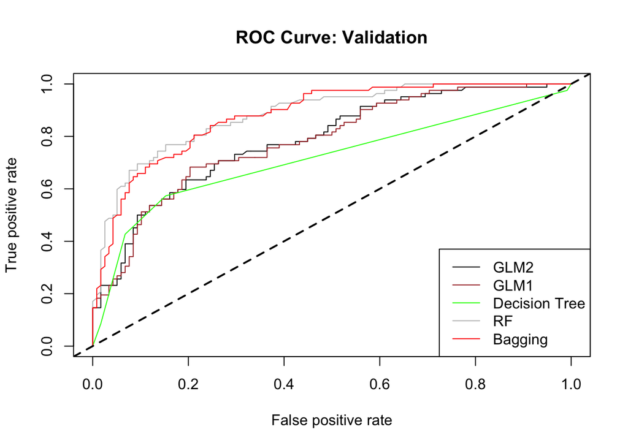

Based on the graphs above, Random Forests seem to perform better than the other predictive models tested in this demonstration.